# InitialAnalysis

Group fiRst

# fiRst Group Project

## Dataset Overview

Objectives of this project is as follows:

# Learning Objectives

- Cleaning dirty data and doing text mining in order to extract insights.
- Visualizing data according to different variables.
- Performing exploratory and explanatory analysis on a mostly untidy dataset.

# Analysis Objectives

- Finding longest and shortest cuts and visualizing them.
- Visualizing cuts at the power plants according to plant, plant type and duration.
- Finding top reasons of electricity cuts with tidy text mining.
- Analyzing cuts vis-a-vis to capacity and total power at the power plant.

```r
# Create a temporary file
tmp<-tempfile(fileext=".csv")
# Download file from repository to the temp file
download.file("https://github.com/MEF-BDA503/gpj18-first/blob/master/dataset_candidates/ArizaBakim-01012008-25112018.csv?raw=true",destfile=tmp)
```

```r
# Reading data. Encoding as Latin-1 is crucial in order to see Turkish characters properly.
cuts<-read.csv(tmp, encoding= "Latin-1", sep = ";")
colnames(cuts) <-c("Plant.Name","UEVCB","Start.Date","End.Date","Established.Power","Power.atOutage","Reason")
# Checking what we have as data.
str(cuts)
```

```
## 'data.frame':    74036 obs. of  7 variables:
##  $ Plant.Name       : Factor w/ 891 levels "","    ","  2.Ünite kazan siklonunda kısmi curuflanma ve vortex silindirinde kısmi yamulmadan dolayı ünite servis harici edildi. ",..: 733 889 345 222 66 508 401 572 730 485 ...
##  $ UEVCB            : Factor w/ 748 levels ""," AES ENTEK ELEKTRİK ÜRETİMİ A.Ş. (KOCAELİ)",..: 635 744 297 186 14 411 342 473 625 389 ...
##  $ Start.Date       : Factor w/ 62953 levels "","1.1.2013 00:00",..: 16880 13994 4693 17488 39657 24102 24857 28100 46422 60030 ...
##  $ End.Date         : Factor w/ 42169 levels "","1.1.2013 16:59",..: 11246 9366 3031 11662 26567 16055 16567 18722 31153 40256 ...
##  $ Established.Power: Factor w/ 595 levels "","0","0,06",..: 256 443 120 224 480 489 531 336 379 420 ...
##  $ Power.atOutage   : Factor w/ 837 levels "","-100","-110",..: 107 9 9 9 9 439 308 9 123 9 ...
##  $ Reason           : Factor w/ 31166 levels "","'F'DEĞİRMENİ ARIZASI",..: 4148 27233 12956 24146 15255 1195 11705 11670 4519 7164 ...
```

```r
# Change type of time and date
cuts$Start.Date <- dmy_hm(cuts$Start.Date)
cuts$End.Date<- dmy_hm(cuts$End.Date)
# Turn power capacity variables into numeric
cuts$Established.Power <- str_replace(cuts$Established.Power,"[,\\.]","")
cuts$Power.atOutage <- str_replace(cuts$Power.atOutage,"[,\\.]","")
cuts$Established.Power <- as.factor(cuts$Established.Power)
cuts$Power.atOutage <- as.factor(cuts$Power.atOutage)
cuts$Established.Power <-as.numeric(levels(cuts$Established.Power))[cuts$Established.Power]
cuts$Power.atOutage <-as.numeric(levels(cuts$Power.atOutage))[cuts$Power.atOutage]
#cuts[c("Established.Power","Power.atOutage")]<-cuts[c("Established.Power","Power.atOutage")]/100
# Removing data that contains NA's.
cuts <- na.omit(cuts)
#Drop UEVÇB column, we do not think it will be any help for analysis.
cuts <- subset(cuts, select=-UEVCB)
# Let's check the data for yearly total cuts.
yearly_cuts <- cuts %>% group_by(year=floor_date(Start.Date,"year")) %>% summarize(Start.Date=n())
yearly_cuts
```

```
## # A tibble: 7 x 2
##   year                Start.Date
##   <dttm>                   <int>
## 1 2012-01-01 00:00:00        335
## 2 2013-01-01 00:00:00       4743
## 3 2014-01-01 00:00:00      10538
## 4 2015-01-01 00:00:00      12116
## 5 2016-01-01 00:00:00      12587
## 6 2017-01-01 00:00:00      10687
## 7 2018-01-01 00:00:00      20271
```

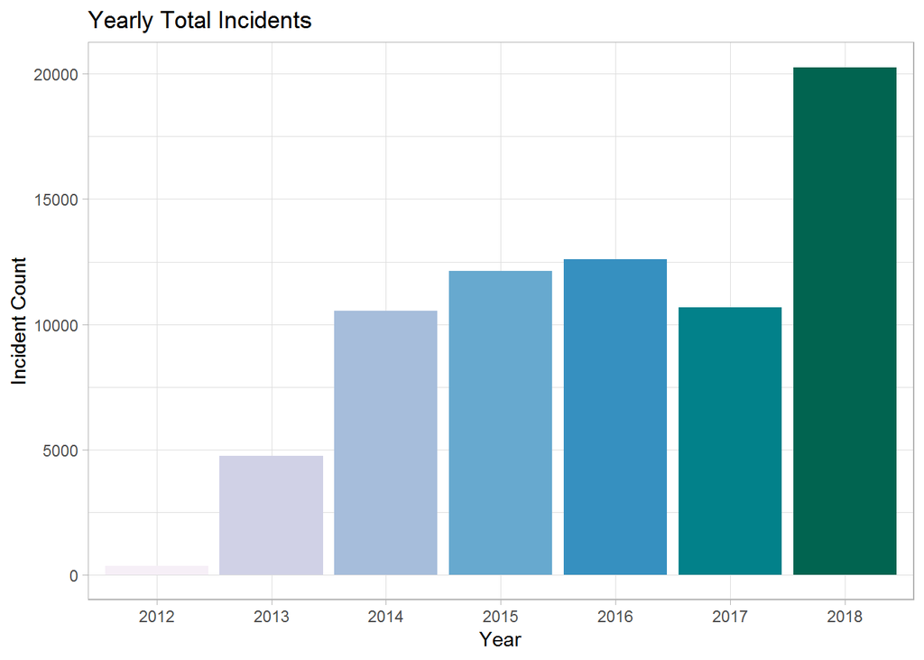

```r
# Let's put the yearly cuts into a bar graph.
ggplot(data=yearly_cuts, aes(y=Start.Date, x=factor(year(year)), fill=factor(year(year))))+
  geom_bar(stat="identity")+
  labs(x="Year", y="Incident Count", title="Yearly Total Incidents")+
  theme_light()+
  scale_fill_brewer(palette="PuBuGn")+
  theme(legend.position="none")
```

# Data Wrangling

The database has mostly text based data. Initial overview of the database shows a lot of errors, some of which come from localization problems, others simply misspelled. In this part, we’ve attempted to make it more tidy by making plant names more distinct, cut reasons more clear.

```r
#Adding süre variable as duration of the cuts as hours and capacity usage ratio at time of cut as capacity usage's ratio to total capacity.

cuts <- cuts %>% mutate(sure = difftime(End.Date,Start.Date,units="hours")) %>% mutate(kapasiteorani = Power.atOutage / Established.Power)
cuts$kapasiteorani <- percent(cuts$kapasiteorani)
# Make all strings lower case so that can be cleaned easier.
cuts <- cuts %>% mutate_at(.vars=c("Plant.Name", "Reason"), funs(tolower))
#With new variables let's see our data.
kable(cuts[1:5,]) %>%
  kable_styling(bootstrap_options = "striped", full_width = F)
```

| Plant.Name | Start.Date | End.Date | Established.Power | Power.atOutage | Reason | sure | kapasiteorani |
| --- | --- | --- | --- | --- | --- | --- | --- |
| sİlopİ tes | 2016-10-17 08:10:00 | 2016-10-17 10:59:00 | 270 | 120 | 3.ünite kazan boru patlağından dolayı servis harici | 2.816667 hours | 44% |
| zorlu enerjİ lüleburgaz santrali | 2016-06-15 15:56:00 | 2016-06-15 15:59:00 | 5796 | 0 | türbİn stoll detected trİp | 0.050000 hours | 0% |
| enerjİsa - hacininoğlu | 2018-10-11 00:22:00 | 2018-10-11 05:59:00 | 14228 | 0 | göl seviyesi | 5.616667 hours | 0% |
| cengİz 240mw samsun gaz yakitli kombİne çevrİm enerjİ santralİ | 2016-03-17 19:01:00 | 2016-03-17 22:59:00 | 2389 | 0 | soğutma suyu arızası | 3.966667 hours | 0% |
| acarsoy denizli doğalgaz santrali | 2014-11-27 08:44:00 | 2014-11-27 23:59:00 | 63 | 0 | gt senkron problemi | 15.250000 hours | 0% |

```r
#Detect similiar names with Fuzzy Text matching
uniqueNames <- unique(cuts$Plant.Name)
name_distances <- list()
i <- 1
for (ind in uniqueNames){
  name_distances[[i]] <- agrep(ind, uniqueNames, value=T)
  i <- i+1
}
name_distances <- unique(Filter(function(x) {length(x) > 1}, name_distances))
#Fixing detected string issues.
cuts$Plant.Name <- cuts$Plant.Name %>%
  str_replace_all("[İı]", "i") %>%
  str_replace_all("enerj.sa", "enerjisa") %>%
  str_replace_all("yeniköy ts", "yeniköy tes") %>%
  str_replace_all("^ova elektrik", "gebze ova elektrik") %>%
  str_replace_all("yatağan .*", "yatağan tes") %>%
  str_replace_all("köklüce$", "köklüce hes") %>%
  str_replace_all(".* entek", "entek") %>%
  str_replace_all("kürtün-hes", "kürtün hes") %>%
  str_replace_all("^rwe_turcas_guney", "denizli rwe_turcas_guney") %>%
  str_replace_all("tekirdağ santrali.*", "modern enerji tekirdağ santrali") %>%
  str_replace_all("karadağ$", "karadağ res") %>%
  str_replace_all(".?menzelet( hes)?", "menzelet hes") %>%
  str_replace_all("\\.", "") %>%
  str_replace_all("hidro(\\s?elektrik santral[ıi]| e\\.?s)", " hes") %>%
  str_replace_all("(termik santral[ıi]|\\sts\\s?)", " tes") %>%
  str_replace_all("tunçbilektes", "tunçbilek tes") %>%
  str_replace_all("d.*(k.*)?ç.*(s.*)?", "dgkç") %>%
  str_replace_all("jeotermal (e.*s.*)", "jes")

cuts$Reason <- cuts$Reason %>%
  str_replace_all("[İı]", "i") %>%
  str_replace_all("t(.r|r.)b.n", "türbin") %>%
  str_replace_all("ar.zas.?.?", "ariza") %>%
  str_replace_all("so.utma", "sogutma") %>%
  str_replace_all("(?<!\\d)\\.", "") %>%
  str_replace_all(".n.te", "unite") %>%
  str_replace_all("reg.lat.r", "regulator")
```

In order to categorise te reasons, we performed a word count Gerekçe column, laying out most encountered words.

```r
gerekcewordcount <- cSplit(cuts, "Reason", sep = " ", direction = "long") %>%
      group_by(Reason) %>%
      summarise(Count = n())
arrange(gerekcewordcount,desc(Count))
```

```
## # A tibble: 12,438 x 2
##    Reason  Count
##    <fct>   <int>
##  1 ariza   36464
##  2 türbin   7176
##  3 kazan    5097
##  4 unite    4557
##  5 dolayi   4310
##  6 gaz      4167
##  7 sogutma  3381
##  8 suyu     3140
##  9 su       3123
## 10 sistemi  2826
## # ... with 12,428 more rows
```

Based on the plant name, we created a new column called Type which stores the type of the plant.

The abbreviations are as following: HES : Hydroelectricty Plant RES : Wind Energy Plant TES : Thermal Power Plant DGKÇ: Natural Gas Combined Cycle Plant JES : Geothermal Energy Plant BES : Biomass Energy Plant

```r
#Categorising type of plants so we can do type based analysis later on.
cuts$Type <- ifelse(grepl(" hes\\s?", cuts$Plant.Name, ignore.case = T), "HES",
         (ifelse(grepl(" res\\s?", cuts$Plant.Name, ignore.case = T), "RES",
         (ifelse(grepl(" tes\\s?", cuts$Plant.Name, ignore.case = T), "TES",
         (ifelse(grepl(" a?d.*k.*ç.*(s.*)?", cuts$Plant.Name, ignore.case = T), "DGKÇ",
         (ifelse(grepl("(jes\\s|jeotermal)", cuts$Plant.Name, ignore.case =T), "JES",
         (ifelse(grepl("biyokütle", cuts$Plant.Name, ignore.case =T), "BES",
                "Other")))))))))))
cuts$Type <- as.factor(cuts$Type)
```

# Data Analysis

Let’s take a look at our final dataset.

```r
str(cuts)
```

```
## 'data.frame':    71277 obs. of  9 variables:
##  $ Plant.Name       : chr  "silopi tes" "zorlu enerji lüleburgaz santrali" "enerjisa - hacininoğlu" "cengiz 240mw samsun gaz yakitli kombine çevrim enerji santrali" ...
##  $ Start.Date       : POSIXct, format: "2016-10-17 08:10:00" "2016-06-15 15:56:00" ...
##  $ End.Date         : POSIXct, format: "2016-10-17 10:59:00" "2016-06-15 15:59:00" ...
##  $ Established.Power: num  270 5796 14228 2389 63 ...
##  $ Power.atOutage   : num  120 0 0 0 0 420 300 0 135 0 ...
##  $ Reason           : chr  "3.unite kazan boru patlağindan dolayi servis harici" "türbin stoll detected trip" "göl seviyesi " "sogutma suyu ariza" ...
##  $ sure             : 'difftime' num  2.81666666666667 0.05 5.61666666666667 3.96666666666667 ...
##   ..- attr(*, "units")= chr "hours"
##  $ kapasiteorani    : chr  "44%" "0%" "0%" "0%" ...
##  $ Type             : Factor w/ 7 levels "BES","DGKÇ","HES",..: 7 5 5 5 5 5 2 5 7 5 ...
```

Here are the explanations for variables:

Santral İsmi : Name of the power plant. Olay başlangıç tarihi : Start date time of the cut. Olay bitiş tarihi : End date/time of the cut. İşletmedeki kurulu güç : Total power at the plant. Olay sırasındaki kapasite : Capacity at the time of incident Gerekçe : Reason of the cut sure : Length of the cut in hours. kapasiteorani : Proportion of the capacity at the time of the cut to max capacity. Type : Type of the plant

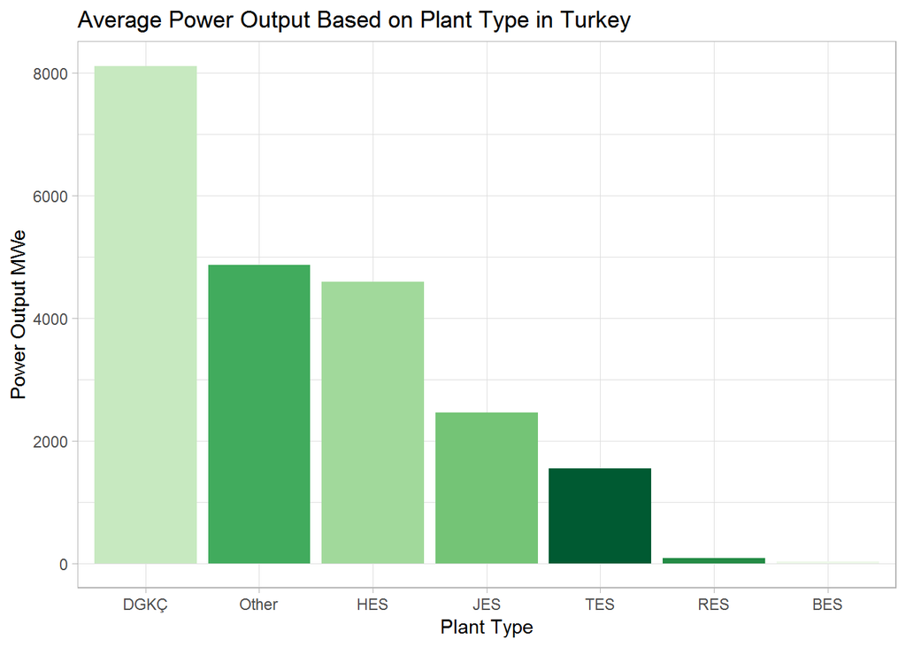

```r
cuts %>%
  group_by(Type) %>%
  summarize(Mean=mean(Established.Power)) %>%
  ggplot(., aes(x=reorder(Type, -Mean), y=Mean, fill=Type))+
    geom_bar(stat="identity")+
    labs(x="Plant Type", y="Power Output MWe", title="Average Power Output Based on Plant Type in Turkey")+
    theme_light()+
    scale_fill_brewer(palette="Greens")+
    theme(legend.position="none")
```

There are two types of cuts at the overall level. Either due to a malfunction or due to planned maintenance. Let’s separate them according to type of cut. We searched for words “bakim” at the reason of cut and assigned “Planned Maintenance” as variable to a new column. All others are assigned “Malfunction”.

```r
bakim <- c("bakim","bakim")
cuts <- cuts%>% mutate(TypeofCut= ifelse(str_detect(Reason,paste(bakim,collapse="|")),"Planned Maintenance","Malfunction"))
```

Our histogram that shows distribution of the cuts durations looks messy due to outliers. Here is a quick workaround by fixing outliers to a maximum value inspired by https://edwinth.github.io/blog/outlier-bin/. Same person has a nice package to deal with such situations, however its dependencies does not work with Shiny.

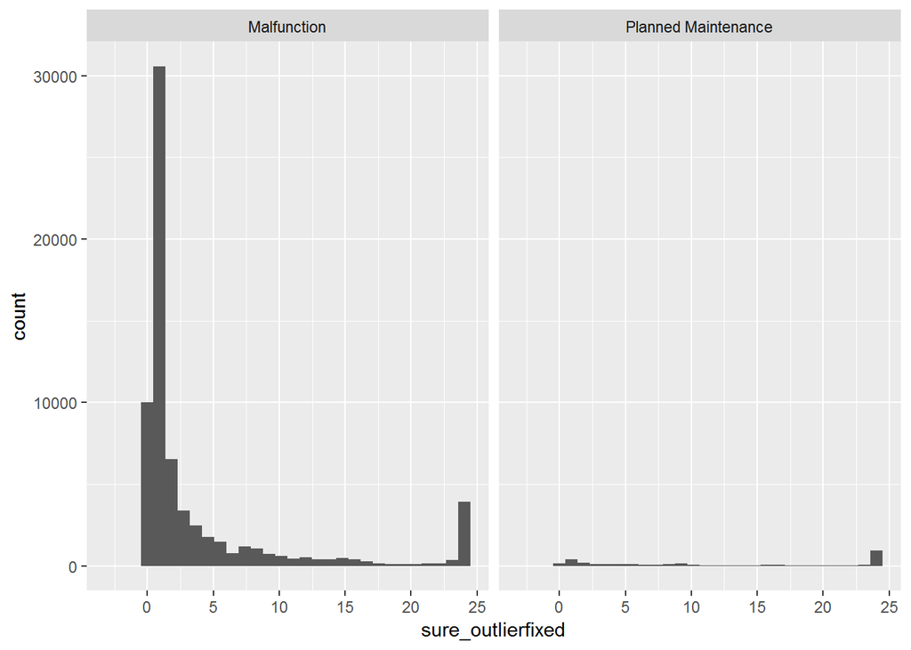

```r
cuts %>% mutate(sure_outlierfixed = ifelse(sure > 24, 24, sure))%>%
ggplot(aes(x=sure_outlierfixed))+
  geom_histogram()+
  facet_wrap(~TypeofCut)
```

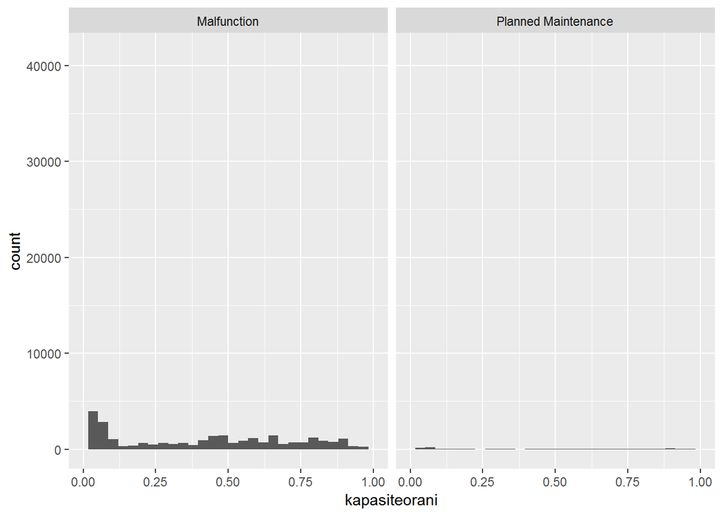

```r
#Note this part has to be polished.
cuts$kapasiteorani <- as.numeric(sub("%","",cuts$kapasiteorani))/100
ggplot(cuts,aes(x=kapasiteorani))+
  geom_histogram()+
  facet_wrap(~TypeofCut)+
    scale_x_continuous(limits = c(0,1))
```